# Fitting Exercise

# Linear models

```r
lm_spec <- linear_reg() %>%
  set_engine("lm")
```

# Linear Model with Dose

```r
lm_dose_workflow <- workflow() %>%
  add_model(lm_spec) %>%
  add_formula(Y ~ DOSE)

lm_dose_fit <- fit(lm_dose_workflow, data = train_data)

lm_dose_pred <- predict(lm_dose_fit, new_data = train_data) %>%
  bind_cols(train_data %>% select(Y))

metrics(lm_dose_pred, truth = Y, estimate = .pred)
```

```
# A tibble: 3 × 3
  .metric .estimator .estimate
  <chr>   <chr>          <dbl>
1 rmse    standard     703.
2 rsq     standard       0.451
3 mae     standard     546.
```

# Linear Model with all Predictors

```r
lm_all_workflow <- workflow() %>%
  add_model(lm_spec) %>%
  add_formula(Y ~ DOSE + AGE + SEX + WT + HT)

lm_all_fit <- fit(lm_all_workflow, data = train_data)

lm_all_pred <- predict(lm_all_fit, new_data = train_data) %>%
  bind_cols(train_data %>% select(Y))

metrics(lm_all_pred, truth = Y, estimate = .pred)
```

```
# A tibble: 3 × 3
  .metric .estimator .estimate
  <chr>   <chr>          <dbl>
1 rmse    standard     627.
2 rsq     standard       0.562
3 mae     standard     486.
```

# Null model

```r
mean_y <- mean(train_data$Y)

null_pred <- train_data %>%
  mutate(.pred = mean_y)

rmse_null <- null_pred %>%
  rmse(truth = Y, estimate = .pred)

rmse_null
```

```
# A tibble: 1 × 3
  .metric .estimator .estimate
  <chr>   <chr>          <dbl>
1 rmse    standard        948.
```

The null model, predicts the mean outcome for all observations, had the highest RMSE being 948. This RMSE value indicates that the predictive preformace of this model is poor. The model that used dose as the only predictor had a lower RMSE value (703), this suggests that dose explains variability in the outcome. The model that uses all predictors had the lowest RMSE (627), which indicates the best preformance.

```r
set.seed(rngseed)

# creates 10 fold CV split
folds <- vfold_cv(train_data, v = 10)
```

# Model using Dose

```r
lm_dose_workflow <- workflow() %>%
  add_model(lm_spec) %>%
  add_formula(Y ~ DOSE)
```

# Model Using All Predictors

```r
lm_all_workflow <- workflow() %>%
  add_model(lm_spec) %>%
  add_formula(Y ~ DOSE + AGE + SEX + WT + HT)
```

# Cross Validation

```r
  dose_cv <- fit_resamples(
  lm_dose_workflow,
  resamples = folds,
  metrics = metric_set(rmse)
)

all_cv <- fit_resamples(
  lm_all_workflow,
  resamples = folds,
  metrics = metric_set(rmse)
)
```

# RMSE and Standard Validation

```r
dose_cv_results <- collect_metrics(dose_cv)
all_cv_results  <- collect_metrics(all_cv)

dose_cv_results
```

```
# A tibble: 1 × 6
  .metric .estimator  mean     n std_err .config
  <chr>   <chr>      <dbl> <int>   <dbl> <chr>
1 rmse    standard    691.    10    67.5 pre0_mod0_post0
```

```r
all_cv_results
```

```
# A tibble: 1 × 6
  .metric .estimator  mean     n std_err .config
  <chr>   <chr>      <dbl> <int>   <dbl> <chr>
1 rmse    standard    646.    10    64.8 pre0_mod0_post0
```

# Different Value for the Random Seed

```r
set.seed(999)

folds2 <- vfold_cv(train_data, v = 10)

dose_cv2 <- fit_resamples(lm_dose_workflow, resamples = folds2, metrics = metric_set(rmse))
all_cv2  <- fit_resamples(lm_all_workflow, resamples = folds2, metrics = metric_set(rmse))

collect_metrics(dose_cv2)
```

```
# A tibble: 1 × 6
  .metric .estimator  mean     n std_err .config
  <chr>   <chr>      <dbl> <int>   <dbl> <chr>
1 rmse    standard    705.    10    45.7 pre0_mod0_post0
```

```r
collect_metrics(all_cv2)
```

```
# A tibble: 1 × 6
  .metric .estimator  mean     n std_err .config
  <chr>   <chr>      <dbl> <int>   <dbl> <chr>
1 rmse    standard    648.    10    52.7 pre0_mod0_post0
```

Changing the random seed resulted in slightly different RMSE values, this could be due to variation in how the data was split into the folds. The pattern stayed the same with the model that used all the predictors having the lowest RMSE value, and the null model having the highest RMSE value.

# This section added by Riley Herber

## Predictions for each model

```r
# Dose model predictions
dose_pred <- predict(lm_dose_fit, new_data = train_data) %>%
  bind_cols(train_data %>% select(Y)) %>%
  mutate(model = "Dose Model")

# All predictor model predictions
all_pred <- predict(lm_all_fit, new_data = train_data) %>%
  bind_cols(train_data %>% select(Y)) %>%
  mutate(model = "All Predictors Model")

# Null model predictions
null_pred <- train_data %>%
  mutate(.pred = mean(train_data$Y),
         model = "Null Model") %>%
  select(Y, .pred, model)
```

## Combine predictions into one dataframe

```r
predictions_df <- bind_rows(
  dose_pred %>% select(Y, .pred, model),
  all_pred %>% select(Y, .pred, model),
  null_pred
)
```

## Observed vs Predicted

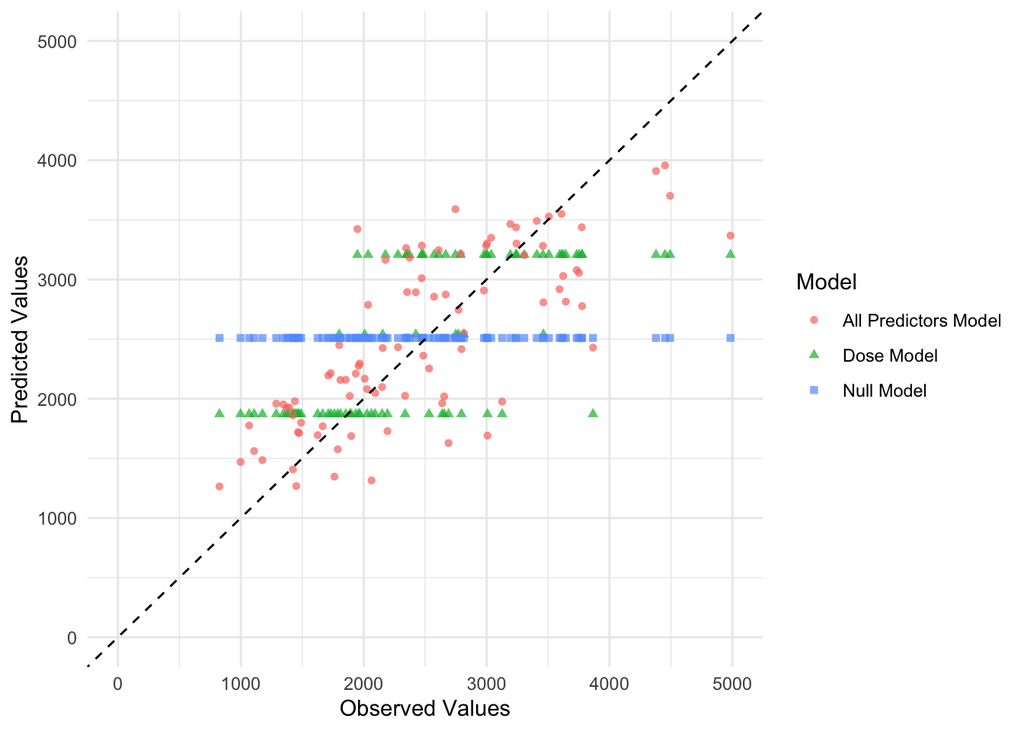

```r
ggplot(predictions_df, aes(x = Y, y = .pred, color = model, shape = model)) +
  geom_point(alpha = 0.7) +
  geom_abline(slope = 1, intercept = 0, linetype = "dashed") +
  coord_cartesian(xlim = c(0, 5000), ylim = c(0, 5000)) +
  labs(
    x = "Observed Values",
    y = "Predicted Values",
    color = "Model",
    shape = "Model"
  ) +
  theme_minimal()
```

For the model that includes only dose as a predictor, the predicted values fall along three horizontal lines because the DOSE variable only takes three distinct values in the dataset.

## Plot All Predictors Model

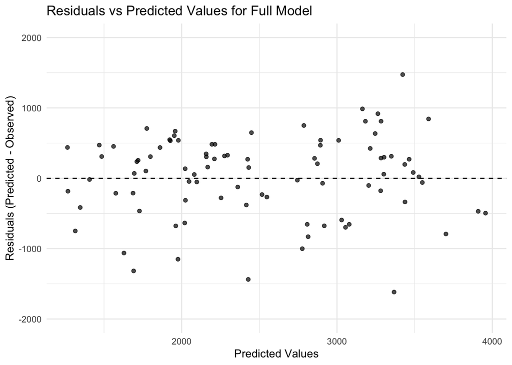

```r
all_residuals <- predict(lm_all_fit, new_data = train_data) %>%
  bind_cols(train_data %>% select(Y)) %>%
  mutate(residual = .pred - Y)

ggplot(all_residuals, aes(x = .pred, y = residual)) +
  geom_point(alpha = 0.7) +
  geom_hline(yintercept = 0, linetype = "dashed") +
  coord_cartesian(ylim = c(-2000, 2000)) +
  labs(
    x = "Predicted Values",
    y = "Residuals (Predicted - Observed)",
    title = "Residuals vs Predicted Values for Full Model"
  ) +
  theme_minimal()
```

# Model predictions and uncertainty

```r
library(rsample)
library(purrr)

set.seed(rngseed)

# 100 bootstrap resamples
dat_bs <- bootstraps(train_data, times = 100)
```

## Fit the model on each bootstrap and make predictions for the original training data

```r
# store predictions
pred_list <- map(dat_bs$splits, function(split) {

dat_sample <- rsample::analysis(split)

  # fit full model on bootstrap sample
  fit_bs <- lm(Y ~ DOSE + AGE + SEX + WT + HT, data = dat_sample)

  # predict on original training data
  predict(fit_bs, newdata = train_data)
})
```

## Combine predictions into a matrix

```r
pred_bs <- do.call(rbind, pred_list)
dim(pred_bs)
```

```
[1] 100  90
```

## Compute median and 89% confidence intervals

```r
preds_ci <- apply(pred_bs, 2, quantile, probs = c(0.055, 0.5, 0.945)) %>%
  t() %>%
  as.data.frame()

colnames(preds_ci) <- c("lower", "median", "upper")
preds_ci$observed <- train_data$Y
preds_ci$predicted <- predict(lm_all_fit, new_data = train_data)$.pred
```

## Plot observed vs. predicted with uncertainty

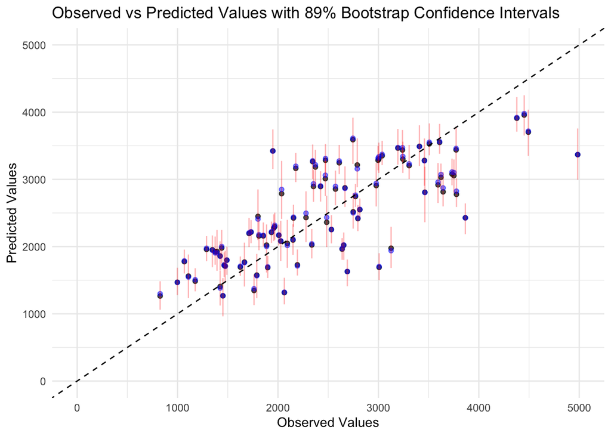

```r
library(ggplot2)

ggplot(preds_ci, aes(x = observed)) +
  geom_point(aes(y = predicted), color = "black", alpha = 0.7) +        # original point estimate
  geom_point(aes(y = median), color = "blue", alpha = 0.5) +             # median from bootstrap
  geom_errorbar(aes(ymin = lower, ymax = upper), width = 0, color = "red", alpha = 0.3) +  # CI
  geom_abline(slope = 1, intercept = 0, linetype = "dashed") +
  coord_cartesian(xlim = c(0, 5000), ylim = c(0, 5000)) +
  labs(
    x = "Observed Values",
    y = "Predicted Values",
    title = "Observed vs Predicted Values with 89% Bootstrap Confidence Intervals"
  ) +
  theme_minimal()
```

The plot of observed versus predicted values with 89% bootstrap confidence intervals shows that the full linear model predicts total drug exposure reasonably well. The black points represent the original model predictions, and most lie close to the 45° line, indicating general agreement between observed and predicted values. The blue points, representing the median predictions from 100 bootstrap samples, largely overlap with the original predictions, demonstrating that the model is stable across resampled datasets. The red vertical lines indicate the 89% confidence intervals, which are relatively narrow for most observations, reflecting low prediction uncertainty, but are wider for a few individuals, likely corresponding to less typical combinations of predictor values. Overall, the pattern suggests that the model captures the main trends in the data, and the bootstrap confirms both the stability and the uncertainty of the predictions.

# Predictions for Training Data Using Model 2

```r
train_pred_all <- predict(lm_all_fit, new_data = train_data) %>%
  bind_cols(train_data %>% select(Y)) %>%
  mutate(dataset = "Training")
```

# Predictions for Test Data Using Model 2

```r
test_pred_all <- predict(lm_all_fit, new_data = test_data) %>%
  bind_cols(test_data %>% select(Y)) %>%
  mutate(dataset = "Test")
```

# Combine Training and Testing Data Predictions

```r
final_pred_df <- bind_rows(train_pred_all, test_pred_all)
```

# Plot for Observed vs Predicted for Both Datasets

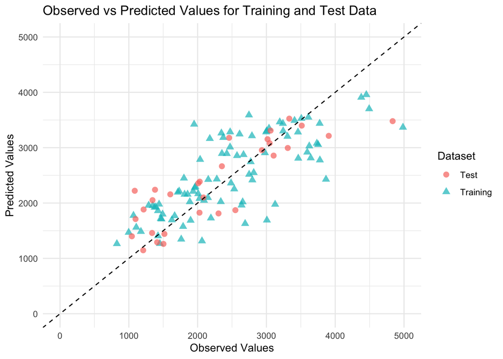

```r
ggplot(final_pred_df, aes(x = Y, y = .pred, color = dataset, shape = dataset)) +
  geom_point(alpha = 0.7, size = 2.5) +
  geom_abline(slope = 1, intercept = 0, linetype = "dashed") +
  coord_cartesian(xlim = c(0, 5000), ylim = c(0, 5000)) +
  labs(
    x = "Observed Values",
    y = "Predicted Values",
    color = "Dataset",
    shape = "Dataset",
    title = "Observed vs Predicted Values for Training and Test Data"
  ) +
  theme_minimal()
```

This plot compares observed vs predicted values for both the training and test data using model 2. The test data points and the training data points are mixed in with each other, which suggests that the model generalizes well to new data and does not overfit.

# Overall Model Assessment

The null model gives us a baseline to compare against, because it does not use any predictors and just predicts the same average value every time. Model 1 uses dose as the only predictor, so the main question is whether dose alone improves prediction. Model 1 has a lower RMSE than the null model, so dose does help explain some of the variation in the outcome. Model 2 includes all predictors, and this model has an even lower RMSE value compared to model 1. The lower RMSE value shows that using all predictors is more accurate. The test data predictions are mixed in with the training data predictions, which means that the model is generalizing to new data rather than overfitting.